# Data Mining Coursework

Surya Ramesh

20/11/2020

# 1 Task 1 - Dataset Exploration and Classification

## 1.1 Task 1a - Dataset Exploration

Background Information is shown in Tables below:

### 1.1.1 Load and View the files

```r
# Loading the three '.csv' Data files into R ,echo = FALSE to suppress code and only show display on R Markdown output

DataSampWater1 <- read.csv(file= "../data/sampleWater1.csv",stringsAsFactors = TRUE, header = TRUE,sep = ",")

DataSampWater2 <- read.csv(file= "../data/sampleWater2.csv",stringsAsFactors = TRUE, header = TRUE,sep = ",")

TestWater <- read.csv(file= "../data/testWater.csv",stringsAsFactors = TRUE, header = TRUE,sep = ",")
```

```r
# Viewing the data set in a separate Window

#View(DataSampWater1)
#View(DataSampWater2)
#View(TestWater)
```

### 1.1.2 Inspecting the data files

```r
#Looking at the number of rows and columns for the datasets

dim(DataSampWater1)
```

```
## [1] 3146   11
```

```r
dim(DataSampWater2)
```

```
## [1] 2485   11
```

```r
dim(TestWater)
```

```
## [1] 2489   11
```

```r
# Look at the column names for the datasets

 colnames(DataSampWater1)
```

```
##  [1] "siteIDScheme" "WBCategory"   "determinandC" "analysed"     "media"
##  [6] "NSamples"     "minValue"     "meanValue"    "maxValue"     "sd"
## [11] "method"
```

```r
 colnames(DataSampWater2)
```

```
##  [1] "siteIDScheme" "WBCategory"   "determinandC" "analysed"     "media"
##  [6] "NSamples"     "minValue"     "meanValue"    "maxValue"     "sd"
## [11] "method"
```

```r
 colnames(TestWater)
```

```
##  [1] "siteIDScheme" "WBCategory"   "determinandC" "analysed"     "media"
##  [6] "NSamples"     "minValue"     "meanValue"    "maxValue"     "sd"
## [11] "method"
```

```r
# Find the number of rows / instances

nrow(DataSampWater1)
```

```
## [1] 3146
```

```r
nrow(DataSampWater2)
```

```
## [1] 2485
```

```r
nrow(TestWater)
```

```
## [1] 2489
```

```r
# Looking at the structure of the data set

str(DataSampWater1)
```

```
## 'data.frame':    3146 obs. of  11 variables:
##  $ siteIDScheme: Factor w/ 2 levels "eionetMonitoringSiteCode",..: 2 1 2 2 1 2 2 2 2 2 ...
##  $ WBCategory  : Factor w/ 4 levels "GW","LW","RW",..: 2 3 2 2 2 2 2 2 2 2 ...
##  $ determinandC: Factor w/ 4 levels "CAS_14798-03-9",..: 3 4 3 2 3 3 2 4 2 2 ...
##  $ analysed    : Factor w/ 1 level "total": 1 1 1 1 1 1 1 1 1 1 ...
##  $ media       : Factor w/ 1 level "water": 1 1 1 1 1 1 1 1 1 1 ...
##  $ NSamples    : int  5 4 2 6 1 1 1 2 7 1 ...
##  $ minValue    : num  37.2 10.5 74.857 0.005 78.5 ...
##  $ meanValue   : num  60.432 10.9 74.928 0.006 78.5 ...
##  $ maxValue    : num  81.6 11.3 75 0.008 78.5 ...
##  $ sd          : num  20.174 NA 0.101 0 NA ...
##  $ method      : Factor w/ 5 levels "EN 25813:1992",..: 4 1 4 2 4 4 2 1 2 2 ...
```

```r
str(DataSampWater2)
```

```
## 'data.frame':    2485 obs. of  11 variables:
##  $ siteIDScheme: Factor w/ 2 levels "eionetMonitoringSiteCode",..: 2 1 2 2 2 2 2 1 2 2 ...
##  $ WBCategory  : Factor w/ 4 levels "GW","LW","RW",..: 2 4 3 2 2 1 2 3 2 2 ...
##  $ determinandC: Factor w/ 4 levels "CAS_14798-03-9",..: 2 4 3 3 2 4 4 4 3 4 ...
##  $ analysed    : Factor w/ 1 level "total": 1 1 1 1 1 1 1 1 1 1 ...
##  $ media       : Factor w/ 1 level "water": 1 1 1 1 1 1 1 1 1 1 ...
##  $ NSamples    : int  3 4 5 5 1 1 2 4 2 1 ...
##  $ minValue    : num  0.041 6.67 87 27.5 0.015 ...
##  $ meanValue   : num  0.047 8.24 89.4 41.88 0.015 ...
##  $ maxValue    : num  0.058 10.6 91 53.25 0.015 ...
##  $ sd          : num  0.009 1.55 1.817 10.186 NA ...
##  $ method      : Factor w/ 5 levels "EN 25813:1992",..: 2 1 1 4 2 1 1 1 4 5 ...
```

```r
str(TestWater)
```

```
## 'data.frame':    2489 obs. of  11 variables:
##  $ siteIDScheme: Factor w/ 2 levels "eionetMonitoringSiteCode",..: 2 1 2 2 2 2 2 1 2 2 ...
##  $ WBCategory  : Factor w/ 4 levels "GW","LW","RW",..: 2 4 3 2 2 1 2 3 2 2 ...
##  $ determinandC: Factor w/ 4 levels "CAS_14798-03-9",..: 2 4 3 3 2 4 4 4 3 4 ...
##  $ analysed    : Factor w/ 1 level "total": 1 1 1 1 1 1 1 1 1 1 ...
##  $ media       : Factor w/ 1 level "water": 1 1 1 1 1 1 1 1 1 1 ...
##  $ NSamples    : int  3 4 5 5 1 1 2 4 2 1 ...
##  $ minValue    : num  0.041 6.67 87 27.5 0.015 ...
##  $ meanValue   : num  0.047 8.24 89.4 41.88 0.015 ...
##  $ maxValue    : num  0.058 10.6 91 53.25 0.015 ...
##  $ sd          : num  0.009 1.55 1.817 10.186 NA ...
##  $ method      : Factor w/ 5 levels "EN 25813:1992",..: 2 1 1 4 2 1 1 1 4 5 ...
```

```r
#Inspecting first and last 10 lines

head(DataSampWater1, n=10)
```

```
##                siteIDScheme WBCategory  determinandC analysed media NSamples
## 1      euMonitoringSiteCode         LW EEA_3131-01-9    total water        5
## 2  eionetMonitoringSiteCode         RW EEA_3132-01-2    total water        4
## 3      euMonitoringSiteCode         LW EEA_3131-01-9    total water        2
## 4      euMonitoringSiteCode         LW CAS_7723-14-0    total water        6
## 5  eionetMonitoringSiteCode         LW EEA_3131-01-9    total water        1
## 6      euMonitoringSiteCode         LW EEA_3131-01-9    total water        1
## 7      euMonitoringSiteCode         LW CAS_7723-14-0    total water        1
## 8      euMonitoringSiteCode         LW EEA_3132-01-2    total water        2
## 9      euMonitoringSiteCode         LW CAS_7723-14-0    total water        7
## 10     euMonitoringSiteCode         LW CAS_7723-14-0    total water        1
##    minValue meanValue maxValue      sd        method
## 1   37.2000   60.4320  81.6000 20.1740      SFS 3040
## 2   10.5000   10.9000  11.3000      NA EN 25813:1992
## 3   74.8570   74.9280  75.0000  0.1010      SFS 3040
## 4    0.0050    0.0060   0.0080  0.0000      SFS 3026
## 5   78.5000   78.5000  78.5000      NA      SFS 3040
## 6   95.5000   95.5000  95.5000      NA      SFS 3040
## 7    0.0040    0.0040   0.0040      NA      SFS 3026
## 8    4.4000    6.4667   8.5333  2.9227 EN 25813:1992
## 9    0.0090    0.0130   0.0170  0.0020      SFS 3026
## 10   0.0047    0.0047   0.0047      NA      SFS 3026
```

```r
tail(DataSampWater1, n=10)
```

```
##              siteIDScheme WBCategory  determinandC analysed media NSamples
## 3137 euMonitoringSiteCode         LW CAS_7723-14-0    total water        2
## 3138 euMonitoringSiteCode         LW EEA_3132-01-2    total water        1
## 3139 euMonitoringSiteCode         LW EEA_3131-01-9    total water        3
## 3140 euMonitoringSiteCode         LW EEA_3132-01-2    total water        2
## 3141 euMonitoringSiteCode         LW EEA_3132-01-2    total water        3
## 3142 euMonitoringSiteCode         LW EEA_3131-01-9    total water        2
## 3143 euMonitoringSiteCode         LW CAS_7723-14-0    total water        2
## 3144 euMonitoringSiteCode         LW EEA_3132-01-2    total water        2
## 3145 euMonitoringSiteCode         LW CAS_7723-14-0    total water        4
## 3146 euMonitoringSiteCode         LW EEA_3131-01-9    total water       10
##      minValue meanValue maxValue      sd                method
## 3137   0.0590    0.0980    0.137  0.0540              SFS 3026
## 3138   7.8000    7.8000    7.800      NA         EN 25813:1992
## 3139  80.1420   83.0280   85.142  2.5870              SFS 3040
## 3140   4.1000    7.2000   10.300  4.3840 SFS 3040 SFS-EN 25813
## 3141   7.0500    7.8610    9.075  1.0700 SFS 3040 SFS-EN 25813
## 3142  58.1660   58.6660   59.166  0.7070              SFS 3040
## 3143   0.0070    0.0070    0.007  0.0000              SFS 3026
## 3144   6.6000    8.2800    9.960  2.3759         EN 25813:1992
## 3145   0.0053    0.0057    0.006  0.0003              SFS 3026
## 3146   0.5000   51.5330   83.333 30.3320              SFS 3040
```

```r
#Inspecting first and last 10 lines

head(DataSampWater2, n=10)
```

```
##                siteIDScheme WBCategory  determinandC analysed media NSamples
## 1      euMonitoringSiteCode         LW CAS_7723-14-0    total water        3
## 2  eionetMonitoringSiteCode         TW EEA_3132-01-2    total water        4
## 3      euMonitoringSiteCode         RW EEA_3131-01-9    total water        5
## 4      euMonitoringSiteCode         LW EEA_3131-01-9    total water        5
## 5      euMonitoringSiteCode         LW CAS_7723-14-0    total water        1
## 6      euMonitoringSiteCode         GW EEA_3132-01-2    total water        1
## 7      euMonitoringSiteCode         LW EEA_3132-01-2    total water        2
## 8  eionetMonitoringSiteCode         RW EEA_3132-01-2    total water        4
## 9      euMonitoringSiteCode         LW EEA_3131-01-9    total water        2
## 10     euMonitoringSiteCode         LW EEA_3132-01-2    total water        1
##    minValue meanValue maxValue      sd                method
## 1    0.0410    0.0470   0.0580  0.0090              SFS 3026
## 2    6.6700    8.2400  10.6000  1.5500         EN 25813:1992
## 3   87.0000   89.4000  91.0000  1.8166         EN 25813:1992
## 4   27.5000   41.8800  53.2500 10.1860              SFS 3040
## 5    0.0150    0.0150   0.0150      NA              SFS 3026
## 6    3.9800    3.9800   3.9800  0.0000         EN 25813:1992
## 7    8.3500    8.5875   8.8250  0.3359         EN 25813:1992
## 8    7.2000   10.2250  11.8000  2.0565         EN 25813:1992
## 9   68.6250   73.3950  78.1660  6.7470              SFS 3040
## 10   7.1429    7.1429   7.1429      NA SFS 3040 SFS-EN 25813
```

```r
tail(DataSampWater2, n=10)
```

```
##              siteIDScheme WBCategory   determinandC analysed media NSamples
## 2476 euMonitoringSiteCode         LW CAS_14798-03-9    total water        6
## 2477 euMonitoringSiteCode         LW  EEA_3131-01-9    total water        1
## 2478 euMonitoringSiteCode         LW  CAS_7723-14-0    total water        3
## 2479 euMonitoringSiteCode         LW  CAS_7723-14-0    total water        2
## 2480 euMonitoringSiteCode         LW CAS_14798-03-9    total water        5
## 2481 euMonitoringSiteCode         RW  EEA_3132-01-2    total water        4
## 2482 euMonitoringSiteCode         LW  CAS_7723-14-0    total water        2
## 2483 euMonitoringSiteCode         LW  EEA_3131-01-9    total water        2
## 2484 euMonitoringSiteCode         LW  EEA_3132-01-2    total water        1
## 2485 euMonitoringSiteCode         LW  EEA_3131-01-9    total water        2
##       minValue meanValue  maxValue      sd                  method
## 2476  0.006440  0.086296  0.435344  0.1320 SFS 3032 + EN ISO 11732
## 2477 71.100000 71.100000 71.100000      NA                SFS 3040
## 2478  0.026000  0.049000  0.073000  0.0230                SFS 3026
## 2479  0.022000  0.027000  0.031000  0.0060                SFS 3026
## 2480  0.002576  0.010304  0.030912  0.0090 SFS 3032 + EN ISO 11732
## 2481  9.700000 11.650000 14.200000  1.8699           EN 25813:1992
## 2482  0.019700  0.019800  0.020000  0.0002                SFS 3026
## 2483 64.714000 66.857000 69.000000  3.0300                SFS 3040
## 2484  8.235000  8.235000  8.235000      NA   SFS 3040 SFS-EN 25813
## 2485 37.500000 58.083000 78.666000 29.1090                SFS 3040
```

```r
#Inspecting first and last 10 lines

head(TestWater, n=10)
```

```
##                siteIDScheme WBCategory  determinandC analysed media NSamples
## 1      euMonitoringSiteCode         LW CAS_7723-14-0    total water        3
## 2  eionetMonitoringSiteCode         TW EEA_3132-01-2    total water        4
## 3      euMonitoringSiteCode         RW EEA_3131-01-9    total water        5
## 4      euMonitoringSiteCode         LW EEA_3131-01-9    total water        5
## 5      euMonitoringSiteCode         LW CAS_7723-14-0    total water        1
## 6      euMonitoringSiteCode         GW EEA_3132-01-2    total water        1
## 7      euMonitoringSiteCode         LW EEA_3132-01-2    total water        2
## 8  eionetMonitoringSiteCode         RW EEA_3132-01-2    total water        4
## 9      euMonitoringSiteCode         LW EEA_3131-01-9    total water        2
## 10     euMonitoringSiteCode         LW EEA_3132-01-2    total water        1
##    minValue meanValue maxValue      sd                method
## 1    0.0410    0.0470   0.0580  0.0090              SFS 3026
## 2    6.6700    8.2400  10.6000  1.5500         EN 25813:1992
## 3   87.0000   89.4000  91.0000  1.8166         EN 25813:1992
## 4   27.5000   41.8800  53.2500 10.1860              SFS 3040
## 5    0.0150    0.0150   0.0150      NA              SFS 3026
## 6    3.9800    3.9800   3.9800  0.0000         EN 25813:1992
## 7    8.3500    8.5875   8.8250  0.3359         EN 25813:1992
## 8    7.2000   10.2250  11.8000  2.0565         EN 25813:1992
## 9   68.6250   73.3950  78.1660  6.7470              SFS 3040
## 10   7.1429    7.1429   7.1429      NA SFS 3040 SFS-EN 25813
```

```r
tail(TestWater, n=10)
```

```
##                  siteIDScheme WBCategory   determinandC analysed media NSamples
## 2480     euMonitoringSiteCode         LW CAS_14798-03-9    total water        5
## 2481     euMonitoringSiteCode         RW  EEA_3132-01-2    total water        4
## 2482     euMonitoringSiteCode         LW  CAS_7723-14-0    total water        2
## 2483     euMonitoringSiteCode         LW  EEA_3131-01-9    total water        2
## 2484     euMonitoringSiteCode         LW  EEA_3132-01-2    total water        1
## 2485     euMonitoringSiteCode         LW  EEA_3131-01-9    total water        2
## 2486 eionetMonitoringSiteCode         TW  EEA_3132-01-2    total water        4
## 2487 eionetMonitoringSiteCode         TW  EEA_3132-01-2    total water       12
## 2488 eionetMonitoringSiteCode         TW  EEA_3132-01-2    total water       12
## 2489 eionetMonitoringSiteCode         TW  EEA_3132-01-2    total water        6
##       minValue meanValue  maxValue      sd                  method
## 2480  0.002576  0.010304  0.030912  0.0090 SFS 3032 + EN ISO 11732
## 2481  9.700000 11.650000 14.200000  1.8699           EN 25813:1992
## 2482  0.019700  0.019800  0.020000  0.0002                SFS 3026
## 2483 64.714000 66.857000 69.000000  3.0300                SFS 3040
## 2484  8.235000  8.235000  8.235000      NA   SFS 3040 SFS-EN 25813
## 2485 37.500000 58.083000 78.666000 29.1090                SFS 3040
## 2486  6.670000  8.240000 10.600000  1.5500           EN 25813:1992
## 2487  8.300000  9.941700 11.300000  0.8565           EN 25813:1992
## 2488  8.900000 10.100000 11.500000  0.7000           EN 25813:1992
## 2489  9.300000 11.100000 12.000000  1.0000           EN 25813:1992
```

```
##                    siteIDScheme  WBCategory         determinandC   analysed
##  eionetMonitoringSiteCode: 154   GW:  64    CAS_14798-03-9: 420   total:3146
##  euMonitoringSiteCode    :2992   LW:2941    CAS_7723-14-0 : 802
##                                  RW: 140    EEA_3131-01-9 : 885
##                                  TW:   1    EEA_3132-01-2 :1039
##
##
##
##    media         NSamples         minValue           meanValue
##  water:3146   Min.   : 1.000   Min.   :  0.00000   Min.   :  0.00100
##               1st Qu.: 2.000   1st Qu.:  0.01619   1st Qu.:  0.02502
##               Median : 2.000   Median :  6.26300   Median :  7.80650
##               Mean   : 3.203   Mean   : 19.07865   Mean   : 22.58591
##               3rd Qu.: 4.000   3rd Qu.: 33.46875   3rd Qu.: 52.27325
##               Max.   :25.000   Max.   :108.33300   Max.   :108.33300
##
##     maxValue               sd                             method
##  Min.   :  0.00129   Min.   : 0.000   EN 25813:1992          :460
##  1st Qu.:  0.03300   1st Qu.: 0.004   SFS 3026               :802
##  Median :  8.92350   Median : 0.809   SFS 3032 + EN ISO 11732:420
##  Mean   : 25.95354   Mean   : 3.917   SFS 3040               :721
##  3rd Qu.: 62.83268   3rd Qu.: 2.987   SFS 3040 SFS-EN 25813  :743
##  Max.   :135.50000   Max.   :53.594
##                      NA's   :314
```

```
##                    siteIDScheme  WBCategory         determinandC  analysed
##  eionetMonitoringSiteCode: 112   GW:  56    CAS_14798-03-9:328   total:2485
##  euMonitoringSiteCode    :2373   LW:2318    CAS_7723-14-0 :632
##                                  RW: 110    EEA_3131-01-9 :700
##                                  TW:   1    EEA_3132-01-2 :825
##
##
##
##    media         NSamples         minValue         meanValue
##  water:2485   Min.   : 1.000   Min.   :  0.000   Min.   :  0.00129
##               1st Qu.: 2.000   1st Qu.:  0.017   1st Qu.:  0.02700
##               Median : 2.000   Median :  6.333   Median :  7.55000
##               Mean   : 3.241   Mean   : 19.627   Mean   : 22.78879
##               3rd Qu.: 4.000   3rd Qu.: 36.666   3rd Qu.: 53.17800
##               Max.   :25.000   Max.   :104.000   Max.   :104.00000
##
##     maxValue               sd                             method
##  Min.   :  0.00129   Min.   : 0.000   EN 25813:1992          :365
##  1st Qu.:  0.03430   1st Qu.: 0.004   SFS 3026               :632
##  Median :  8.82500   Median : 0.807   SFS 3032 + EN ISO 11732:328
##  Mean   : 25.80856   Mean   : 3.520   SFS 3040               :561
##  3rd Qu.: 60.66600   3rd Qu.: 2.842   SFS 3040 SFS-EN 25813  :599
##  Max.   :137.50000   Max.   :67.882
##                      NA's   :258
```

```
##                    siteIDScheme  WBCategory         determinandC  analysed
##  eionetMonitoringSiteCode: 116   GW:  56    CAS_14798-03-9:328   total:2489
##  euMonitoringSiteCode    :2373   LW:2318    CAS_7723-14-0 :632
##                                  RW: 110    EEA_3131-01-9 :700
##                                  TW:   5    EEA_3132-01-2 :829
##
##
##
##    media         NSamples         minValue         meanValue
##  water:2489   Min.   : 1.000   Min.   :  0.000   Min.   :  0.00129
##               1st Qu.: 2.000   1st Qu.:  0.017   1st Qu.:  0.02700
##               Median : 2.000   Median :  6.367   Median :  7.55560
##               Mean   : 3.249   Mean   : 19.608   Mean   : 22.76799
##               3rd Qu.: 4.000   3rd Qu.: 36.666   3rd Qu.: 53.16600
##               Max.   :25.000   Max.   :104.000   Max.   :104.00000
##
##     maxValue               sd                             method
##  Min.   :  0.00129   Min.   : 0.000   EN 25813:1992          :369
##  1st Qu.:  0.03430   1st Qu.: 0.004   SFS 3026               :632
##  Median :  8.83300   Median : 0.808   SFS 3032 + EN ISO 11732:328
##  Mean   : 25.78533   Mean   : 3.515   SFS 3040               :561
##  3rd Qu.: 60.60000   3rd Qu.: 2.837   SFS 3040 SFS-EN 25813  :599
##  Max.   :137.50000   Max.   :67.882
##                      NA's   :258
```

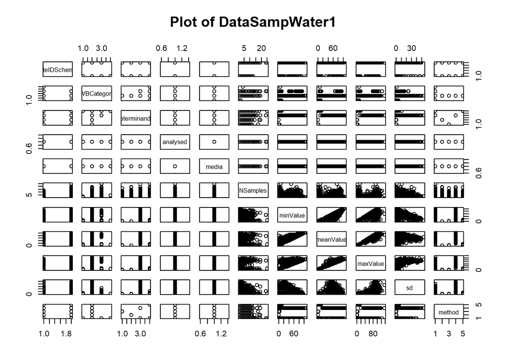

```r
#Basic plot of the individual datasets

plot(DataSampWater1,main = "Plot of DataSampWater1")
```

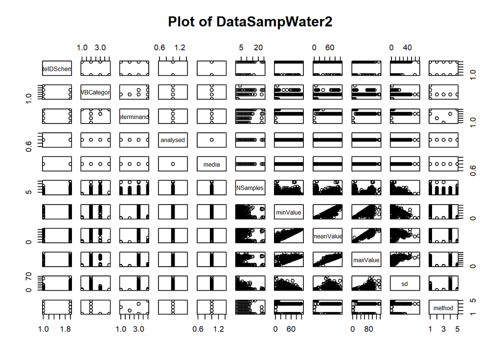

```r
plot(DataSampWater2,main = "Plot of DataSampWater2")
```

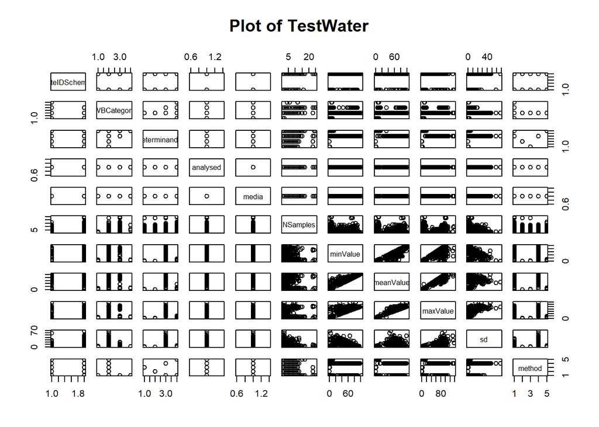

```r
plot(TestWater,main ="Plot of TestWater")
```

The attributes and the relations can be seen above. The levels of the categorical variables can also be seen as a distinct vertical lines and the variations in range for numerical attributes is seen as distinct horizontal lines.A closer look at the distributions is done with the plots below.

### 1.1.3 Class distribution

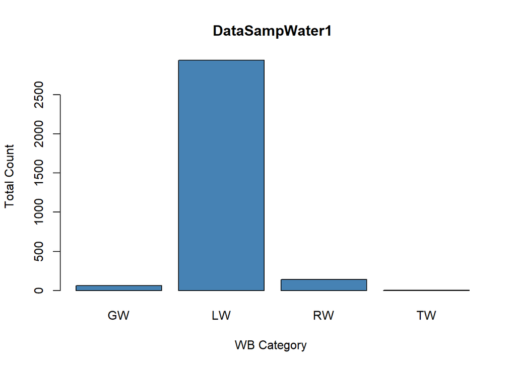

```r
# Checking for class distribution in the three data sets

plot(DataSampWater1$WBCategory, main = "DataSampWater1",xlab ="WB Category ", ylab ="Total Count", col = "steel blue" )
```

```r
count(DataSampWater1,DataSampWater1$WBCategory)       # Looking at actual numbers of WBCategory in DataSampWater1
```

```
##   DataSampWater1$WBCategory    n
## 1                        GW   64
## 2                        LW 2941
## 3                        RW  140
## 4                        TW    1
```

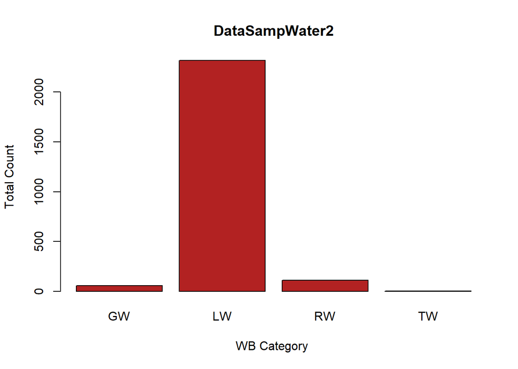

```r
plot(DataSampWater2$WBCategory,main = "DataSampWater2", xlab ="WB Category ", ylab ="Total Count", col = "firebrick" )
```

```r
count(DataSampWater2,DataSampWater2$WBCategory)       # Looking at actual numbers of WBCategory in DataSampWater2
```

```
##   DataSampWater2$WBCategory    n
## 1                        GW   56
## 2                        LW 2318
## 3                        RW  110
## 4                        TW    1
```

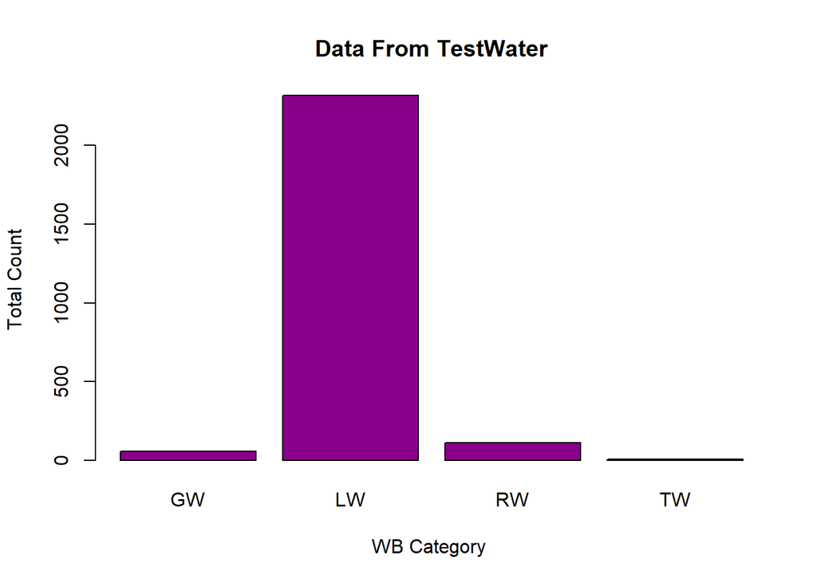

```r
plot(TestWater$WBCategory,main = "Data From TestWater", xlab ="WB Category ", ylab ="Total Count", col = "darkmagenta" )
```

```r
count(TestWater,TestWater$WBCategory)                         # Looking at actual numbers of WBCategory in DataSampWater2
```

```
##   TestWater$WBCategory    n
## 1                   GW   56
## 2                   LW 2318
## 3                   RW  110
## 4                   TW    5
```

Looking at the class distributions and summary above:

• Dataset is imbalanced for DataSampWater 1 - out of 3146 instances, LW has a lot more instances (2941), than RW(140), GW(64) and only one for TW. The distribution is similar for DatasampWater2 and TestWater as well.

• Majority of the data provided is for LW (Lake water) – so data could be skewed for it, which is not ideal.

• There is only one example for TW(Transitional water) in each of the sample dataset to be used for training and hence predicting it will be unlikely .

• The Test Water dataset has 5 instances of TW which is more than the combined training set. This data would have been more useful in the training set.